# TD 1 — Régression de Poisson (R)

Année universitaire 2025–2026 • Parcours Économie de la santé & Développement durable

Pierre Beaucoral

2025-11-27

# 1 Objectifs du TD

- Construire un tableau **comptages + exposition** (population à risque).
- Estimer un **GLM Poisson** avec **offset** (*log-exposition*).
- Évaluer l’ajustement : **Déviance** & **Pearson**.
- Comparer des modèles (**LR test**).
- Interpréter en **IRR** et produire des **comptes attendus**.
- Diagnostiquer la **sur-dispersion** et évoquer Quasi-Poisson / NB.

# 2 Rappel rapide — Modèle de Poisson

**Formulation**

- $Y_i \sim \text{Poisson}(\mu_i)$, $\mathbb{E}[Y_i]=\mu_i$, $\mathrm{Var}(Y_i)=\mu_i$
- Lien log : $\log(\mu_i) ;=; \beta_0 + \beta_1 X_{1i} + \cdots + \beta_p X_{pi} + \log(\text{exposition}_i)$
- L’**offset** $\log(\text{exposition}_i)$ ajuste la taille de population/temps.
- Interprétation : $e^{\beta_j} = \text{IRR}_j$ (ratio de taux d’incidence).

**Diagnostics** : Déviance, Pearson, sur-dispersion (sinon Quasi-Poisson / NB).

# 3 Données & packages

Contexte : décès **cancer du poumon** × classes d’**âge** × **statut tabagique**.  
**Exposition** = population (centaines de milliers → convertir en personnes).

```r
#| label: setup
# installer si nécessaire : install.packages(c("readxl","dplyr","tidyr","janitor","ggplot2","broom","gt","performance","DescTools"))
library(readxl)
library(dplyr)
library(tidyr)
library(janitor)
library(ggplot2)
library(broom)
library(gt)
library(performance)   # check_overdispersion
library(DescTools)     # PChisq for GOF (si besoin)
```

# 4 Import & nettoyage

```r
data_path <- "data/smoking_dat.xlsx"

df <- read_excel(data_path) |>
  clean_names() |>
  rename(
    age = matches("^age$|^age_class|^agecat"),
    smoking_status = matches("^smoking|^smoke"),
    population = matches("^pop|^population"),
    deaths = matches("^deaths|^dead")
  )

glimpse(df)
```

```
Rows: 36
Columns: 4
$ age            <chr> "40-44", "45-59", "50-54", "55-59", "60-64", "65-69", "…
$ smoking_status <chr> "no", "no", "no", "no", "no", "no", "no", "no", "no", "…
$ population     <dbl> 656, 359, 249, 632, 1067, 897, 668, 361, 274, 145, 104,…
$ deaths         <dbl> 18, 22, 19, 55, 117, 170, 179, 120, 120, 2, 4, 3, 38, 1…
```

# 5 **Encodage des facteurs**

```r
df <- df |>
  mutate(
    age = factor(age, ordered = FALSE),
    smoking_status = factor(smoking_status, ordered = FALSE)
  )

levels(df$age); levels(df$smoking_status)
```

```
[1] "40-44" "45-59" "50-54" "55-59" "60-64" "65-69" "70-74" "75-79" "80+"
```

```
[1] "cigarPipeOnly"  "cigarretteOnly" "cigarrettePlus" "no"
```

# 6 Exposition & échelle

Population en **centaines de milliers** → convertir en **personnes**.

```r
expo_personnes <- TRUE
scale_factor <- 1e5

df <- df |>
  mutate(
    exposure = if (expo_personnes) population * scale_factor else population
  )

summary(df$exposure)
```

```
     Min.   1st Qu.    Median      Mean   3rd Qu.      Max.
  9800000  36925000  85850000 155894444 230550000 605200000
```

# 7 Modèle Poisson (mod1)

```r
mod1 <- glm(deaths ~ smoking_status + age + offset(log(exposure)),
            family = poisson(link = "log"), data = df)
summary(mod1)
```

```
Call:
glm(formula = deaths ~ smoking_status + age + offset(log(exposure)),
    family = poisson(link = "log"), data = df)

Coefficients:
                              Estimate Std. Error  z value Pr(>|z|)
(Intercept)                  -15.14514    0.06783 -223.293  < 2e-16 ***
smoking_statuscigarretteOnly   0.36915    0.03791    9.737  < 2e-16 ***
smoking_statuscigarrettePlus   0.17015    0.03643    4.671 3.00e-06 ***
smoking_statusno              -0.04781    0.04699   -1.017    0.309
age45-59                       0.55388    0.07999    6.924 4.38e-12 ***
age50-54                       0.98039    0.07682   12.762  < 2e-16 ***
age55-59                       1.37946    0.06526   21.138  < 2e-16 ***
age60-64                       1.65423    0.06257   26.439  < 2e-16 ***
age65-69                       1.99817    0.06279   31.824  < 2e-16 ***
age70-74                       2.27141    0.06435   35.296  < 2e-16 ***
age75-79                       2.55858    0.06778   37.746  < 2e-16 ***
age80+                         2.84692    0.07242   39.310  < 2e-16 ***
---
Signif. codes:  0 '***' 0.001 '**' 0.01 '*' 0.05 '.' 0.1 ' ' 1

(Dispersion parameter for poisson family taken to be 1)

    Null deviance: 4055.984  on 35  degrees of freedom
Residual deviance:   21.487  on 24  degrees of freedom
AIC: 285.51

Number of Fisher Scoring iterations: 4
```

**Idée** : on modélise un **taux** (décès / exposition). L’**offset** impose un coefficient de 1 sur $\log(\text{exposition})$ .

# 8 Qualité d’ajustement

Déviance vs modèle saturé et **Pearson GOF** (mêmes df résiduels).

```r
dev_stat  <- deviance(mod1)
dev_df    <- df.residual(mod1)
dev_p     <- pchisq(dev_stat, dev_df, lower.tail = FALSE)

mu_hat    <- fitted(mod1)
y_obs     <- df$deaths
pearson   <- sum((y_obs - mu_hat)^2 / mu_hat)
pearson_p <- pchisq(pearson, dev_df, lower.tail = FALSE)

tibble(
  test = c("Deviance GOF", "Pearson GOF"),
  statistic = c(dev_stat, pearson),
  df = c(dev_df, dev_df),
  p_value = c(dev_p, pearson_p)
) |>
  gt()
```

| test | statistic | df | p_value |
| --- | --- | --- | --- |
| Deviance GOF | 21.48674 | 24 | 0.6098720 |
| Pearson GOF | 20.61936 | 24 | 0.6610658 |

# 9 Test LR — Rôle du tabac

Comparer **modèle sans tabac** (mod0) vs **mod1**.

```r
mod0 <- glm(deaths ~ age + offset(log(exposure)),
            family = poisson, data = df)

anova(mod0, mod1, test = "Chisq")
```

```
Analysis of Deviance Table

Model 1: deaths ~ age + offset(log(exposure))
Model 2: deaths ~ smoking_status + age + offset(log(exposure))
  Resid. Df Resid. Dev Df Deviance  Pr(>Chi)
1        27    191.723
2        24     21.487  3   170.24 < 2.2e-16 ***
---
Signif. codes:  0 '***' 0.001 '**' 0.01 '*' 0.05 '.' 0.1 ' ' 1
```

**Conclusion attendue** : le **statut tabagique** améliore significativement l’ajustement.

# 10 Variante binaire “fumeur de cigarette”

Créer `cigarette_user` = 1 si l’étiquette contient “cigarette”.

```r
df <- df |>
  mutate(
    cigarette_user = as.integer(grepl("cigarrette", tolower(as.character(smoking_status)))))

table(df$cigarette_user, df$smoking_status)
```

```
    cigarPipeOnly cigarretteOnly cigarrettePlus no
  0             9              0              0  9
  1             0              9              9  0
```

## 10.1 **Modèle (mod2)**

```r
mod2 <- glm(deaths ~ cigarette_user + age + offset(log(exposure)),
            family = poisson, data = df)

summary(mod2)
```

```
Call:
glm(formula = deaths ~ cigarette_user + age + offset(log(exposure)),
    family = poisson, data = df)

Coefficients:
                Estimate Std. Error  z value Pr(>|z|)
(Intercept)    -15.15590    0.06378 -237.625  < 2e-16 ***
cigarette_user   0.26910    0.02757    9.762  < 2e-16 ***
age45-59         0.55342    0.07999    6.919 4.56e-12 ***
age50-54         0.98480    0.07682   12.820  < 2e-16 ***
age55-59         1.37640    0.06526   21.092  < 2e-16 ***
age60-64         1.64629    0.06256   26.317  < 2e-16 ***
age65-69         1.99023    0.06277   31.708  < 2e-16 ***
age70-74         2.26143    0.06432   35.161  < 2e-16 ***
age75-79         2.54560    0.06766   37.626  < 2e-16 ***
age80+           2.82907    0.07215   39.211  < 2e-16 ***
---
Signif. codes:  0 '***' 0.001 '**' 0.01 '*' 0.05 '.' 0.1 ' ' 1

(Dispersion parameter for poisson family taken to be 1)

    Null deviance: 4055.984  on 35  degrees of freedom
Residual deviance:   92.237  on 26  degrees of freedom
AIC: 352.26

Number of Fisher Scoring iterations: 4
```

## 10.2 Anova

```r
anova(mod2, test = "Chisq")
```

```
Analysis of Deviance Table

Model: poisson, link: log

Response: deaths

Terms added sequentially (first to last)

               Df Deviance Resid. Df Resid. Dev  Pr(>Chi)
NULL                              35     4056.0
cigarette_user  1     58.3        34     3997.6 2.195e-14 ***
age             8   3905.4        26       92.2 < 2.2e-16 ***
---
Signif. codes:  0 '***' 0.001 '**' 0.01 '*' 0.05 '.' 0.1 ' ' 1
```

# 11 mod1 vs mod2 (granularité du tabac)

```r
anova(mod2, mod1, test = "Chisq")
```

```
Analysis of Deviance Table

Model 1: deaths ~ cigarette_user + age + offset(log(exposure))
Model 2: deaths ~ smoking_status + age + offset(log(exposure))
  Resid. Df Resid. Dev Df Deviance  Pr(>Chi)
1        26     92.237
2        24     21.487  2    70.75 4.334e-16 ***
---
Signif. codes:  0 '***' 0.001 '**' 0.01 '*' 0.05 '.' 0.1 ' ' 1
```

- Si **mod1** (4 catégories) ≫ **mod2** (binaire), alors le **type** de produit compte.

# 12 IRR & IC 95%

```r
tidy(mod1, conf.int = TRUE, exponentiate = TRUE) |>
  select(term, estimate, conf.low, conf.high, p.value) |>
  arrange(desc(estimate)) |>
  gt() |>
  tab_header(title = "IRR (modèle 1) — exp(coef) avec IC 95%")
```

IRR (modèle 1) — exp(coef) avec IC 95%

| term | estimate | conf.low | conf.high | p.value |
| --- | --- | --- | --- | --- |
| age80+ | 1.723470e+01 | 1.496968e+01 | 1.988626e+01 | 0.000000e+00 |
| age75-79 | 1.291740e+01 | 1.132626e+01 | 1.477500e+01 | 0.000000e+00 |
| age70-74 | 9.693017e+00 | 8.558760e+00 | 1.101560e+01 | 6.852385e-273 |
| age65-69 | 7.375556e+00 | 6.533324e+00 | 8.357251e+00 | 2.978913e-222 |
| age60-64 | 5.229045e+00 | 4.633991e+00 | 5.922596e+00 | 4.943059e-154 |
| age55-59 | 3.972749e+00 | 3.501347e+00 | 4.522490e+00 | 3.581870e-99 |
| age50-54 | 2.665487e+00 | 2.294116e+00 | 3.100656e+00 | 2.658489e-37 |
| age45-59 | 1.739985e+00 | 1.487796e+00 | 2.036040e+00 | 4.376858e-12 |
| smoking_statuscigarretteOnly | 1.446509e+00 | 1.343418e+00 | 1.558691e+00 | 2.099342e-22 |
| smoking_statuscigarrettePlus | 1.185481e+00 | 1.104252e+00 | 1.273769e+00 | 3.001586e-06 |
| smoking_statusno | 9.533182e-01 | 8.692799e-01 | 1.045138e+00 | 3.090007e-01 |
| (Intercept) | 2.645745e-07 | 2.312255e-07 | 3.016715e-07 | 0.000000e+00 |

**Lecture** : $IRR>1$ → taux ↑ vs référence ; $IRR<1$ → taux ↓.

# 13 Observé vs Attendu

```r
df_preds <- df |>
  mutate(
    y_obs = deaths,
    mu_hat = fitted(mod1)
  )

df_preds |>
  select(age, smoking_status, exposure, y_obs, mu_hat) |>
  arrange(age, smoking_status) |>
  gt() |>
  fmt_number(columns = c(exposure, y_obs, mu_hat), decimals = 2)
```

| age | smoking_status | exposure | y_obs | mu_hat |
| --- | --- | --- | --- | --- |
| 40-44 | cigarPipeOnly | 14,500,000.00 | 2.00 | 3.84 |
| 40-44 | cigarretteOnly | 341,000,000.00 | 124.00 | 130.50 |
| 40-44 | cigarrettePlus | 453,100,000.00 | 149.00 | 142.11 |
| 40-44 | no | 65,600,000.00 | 18.00 | 16.55 |
| 45-59 | cigarPipeOnly | 10,400,000.00 | 4.00 | 4.79 |
| 45-59 | cigarretteOnly | 223,900,000.00 | 140.00 | 149.10 |
| 45-59 | cigarrettePlus | 303,000,000.00 | 169.00 | 165.36 |
| 45-59 | no | 35,900,000.00 | 22.00 | 15.76 |
| 50-54 | cigarPipeOnly | 9,800,000.00 | 3.00 | 6.91 |
| 50-54 | cigarretteOnly | 185,100,000.00 | 187.00 | 188.82 |
| 50-54 | cigarrettePlus | 226,700,000.00 | 193.00 | 189.53 |
| 50-54 | no | 24,900,000.00 | 19.00 | 16.74 |
| 55-59 | cigarPipeOnly | 37,200,000.00 | 38.00 | 39.10 |
| 55-59 | cigarretteOnly | 327,000,000.00 | 514.00 | 497.17 |
| 55-59 | cigarrettePlus | 468,200,000.00 | 576.00 | 583.40 |
| 55-59 | no | 63,200,000.00 | 55.00 | 63.33 |
| 60-64 | cigarPipeOnly | 84,600,000.00 | 113.00 | 117.04 |
| 60-64 | cigarretteOnly | 379,100,000.00 | 778.00 | 758.66 |
| 60-64 | cigarrettePlus | 605,200,000.00 | 1,001.00 | 992.58 |
| 60-64 | no | 106,700,000.00 | 117.00 | 140.73 |
| 65-69 | cigarPipeOnly | 94,900,000.00 | 173.00 | 185.19 |
| 65-69 | cigarretteOnly | 242,100,000.00 | 689.00 | 683.37 |
| 65-69 | cigarrettePlus | 388,000,000.00 | 901.00 | 897.57 |
| 65-69 | no | 89,700,000.00 | 170.00 | 166.87 |
| 70-74 | cigarPipeOnly | 82,400,000.00 | 212.00 | 211.32 |
| 70-74 | cigarretteOnly | 119,500,000.00 | 432.00 | 443.30 |
| 70-74 | cigarrettePlus | 203,300,000.00 | 613.00 | 618.07 |
| 70-74 | no | 66,800,000.00 | 179.00 | 163.31 |
| 75-79 | cigarPipeOnly | 66,700,000.00 | 243.00 | 227.95 |
| 75-79 | cigarretteOnly | 43,600,000.00 | 214.00 | 215.54 |
| 75-79 | cigarrettePlus | 87,100,000.00 | 337.00 | 352.89 |
| 75-79 | no | 36,100,000.00 | 120.00 | 117.62 |
| 80+ | cigarPipeOnly | 53,700,000.00 | 253.00 | 244.86 |
| 80+ | cigarretteOnly | 11,300,000.00 | 63.00 | 74.53 |
| 80+ | cigarrettePlus | 34,500,000.00 | 189.00 | 186.49 |
| 80+ | no | 27,400,000.00 | 120.00 | 119.11 |

**Graphique**

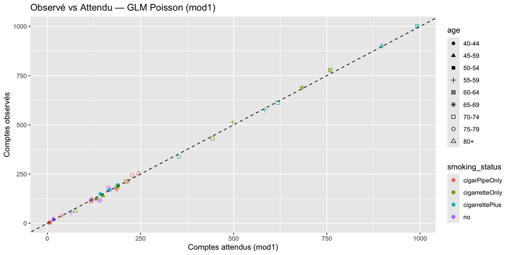

```r
shapes_9 <- c(16, 17, 15, 3, 7, 8, 0, 1, 2)
ggplot(df_preds, aes(mu_hat, y_obs, color = smoking_status, shape = age)) +
  geom_point(size = 2) +
  geom_abline(intercept = 0, slope = 1, linetype = 2) +
  scale_shape_manual(values = shapes_9) +
  labs(x = "Comptes attendus (mod1)", y = "Comptes observés",
       title = "Observé vs Attendu — GLM Poisson (mod1)")
```

# 14 Sur-dispersion ?

```r
check_overdispersion(mod1)
```

```
# Overdispersion test

       dispersion ratio =  0.859
  Pearson's Chi-Squared = 20.619
                p-value =  0.661
```

- Si sur-dispersion marquée :
  - **Quasi-Poisson** `family = quasipoisson` (SE corrigés),
  - **NB** `MASS::glm.nb(...)` (variance flexible).

# 15 Bonnes pratiques (rapide)

- Toujours **documenter l’offset** et l’unité d’exposition.
- Vérifier les **cellules rares** (μ̂ très petits) avant χ².
- **Comparer** modèles (parcimonie vs granularité).
- **Communiquer** en **IRR** + **IC**.
- **Tester** la robustesse (Quasi-Poisson / NB).

# 16 Fin — Ressources

- GLM (Poisson) dans R : `?glm`, `family = poisson`
- Diagnostics : `performance::check_overdispersion`
- Alternatives : `quasipoisson`, `MASS::glm.nb`
- Visualisation : `ggplot2`